# Group Project 2

Remote Group 13

11/06/2021

```r
library(ggplot2)
library(limma)
library(ggfortify)
library(tidyverse)
library(GEOquery)
library(MASS)
library(naniar)
library(dendextend)
library(org.Hs.eg.db)
library(edgeR)
library(Glimma)
library(Homo.sapiens)
library(gplots)
library(dplyr)
library(AnnotationDbi)
library(RColorBrewer)
library(e1071)
```

# Summary

## Aim

The aim of this study conducted by Wang and colleagues was to use both transcriptomic databases and SVM-based pattern recognition to select biomarkers that could be used in predicting and preventing gestational diabetes mellitus (GDM) as well as determine links, if any, to other correlating diseases such as Type 2 Diabetes and immune disorders.

## Methods

The study first screened 63 samples (32 GDM patient samples, 31 control samples) from a dataset collected from GEO (GSE70493) for GDM-specific biomarkers. The study then utilized the edgeR package to screen out the differentially expressed genes between the two groups. The paper then proceeded to use the Poisson regression model and Empirical Bayes method to account for biological variability and improve the overall reliability of future inferences.

Hierarchical clustering was then performed to create a heatmap expressing the gene expression data analysis, and a volcano plot was created in order to observe the significance of the microarrays gene selection criteria. Through the use of databases such as DAVID (database for annotation, visualization, and integration discovery) and KEGG (Kyoto encyclopedia of genes and genomes), a gene regulatory network was then constructed in order to select GDM biomarker candidates (utilizing prior literature sourced from PubMed).

Once biomarker candidates were located, all were subjected to the implementation of a SVM (support vector machine) to determine the prediction capacity of the model. Finally, a 10-fold cross validation was performed to determine the validity of the study’s findings and observe the error rate.

## Results

A total of 6 genes were found to serve as good predictors of GDM and thus have the potential to serve as biomarkers for GDM prediction and diagnosis. The biomarkers found were all derived from the HLA superfamily - HLA-DQA1, HLA-DQA2, HLA-DRA, HLA-DRB1, HLA-DRB4 and HLA-DRB5.

# Experimental Design

The aforementioned methodologies of the paper can be split into 4 components:  
1. Obtaining of gene expression profiles  
2. Analysis of genes to narrow down potential biomarkers  
3. Obtaining of potential GDM biomarkers  
4. Creation of prediction models for validity

## Workflow

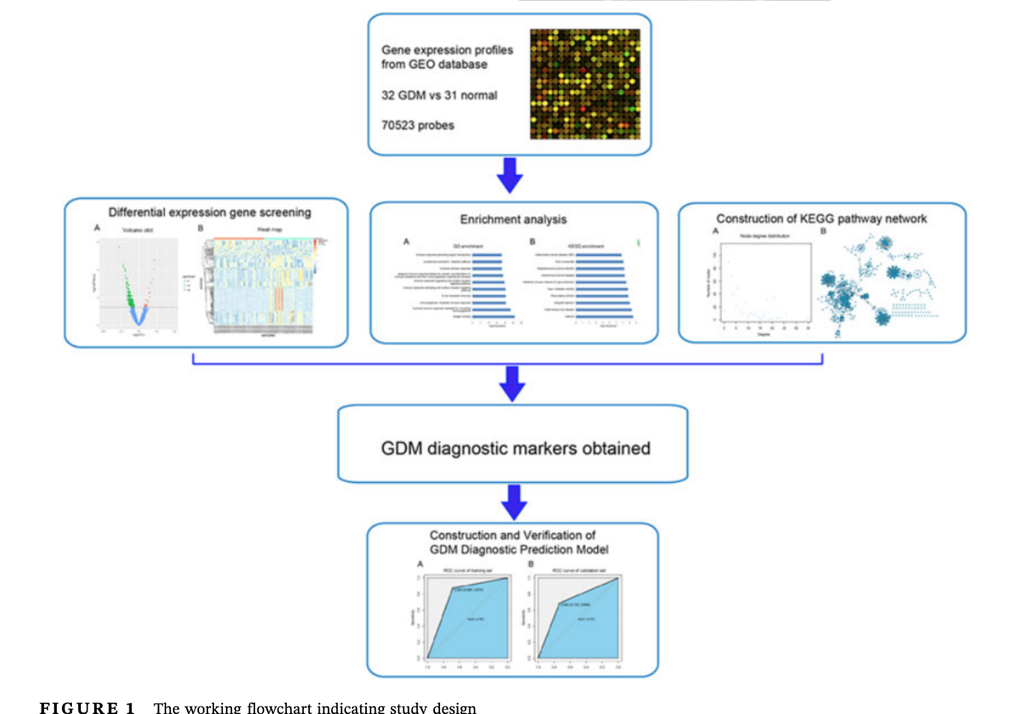

```r
knitr::include_graphics("Capture.png")
```

# Reproduced Report

## Load Data

```r
gset <- getGEO("GSE70493",getGPL=TRUE, destdir = ".")[[1]]
```

## Rename Pheno

```r
exprs <- exprs(gset)
geneAnno <- fData(gset)
pheno <- pData(gset)
view(pheno)
colnames(pheno) <- gsub(" ", "_", colnames(pheno))
colnames(pheno) <- sub(":ch1", "", colnames(pheno))

x <- log2(exprs)
```

## Remove Missing Data

```r
Data <- na.omit(gset)
```

This was not explicitly stated that it was done in the current paper. We decided to remove missing data anyway in order to get more accurate results/findings to compare to the original papers own findings.

## Creation of Design Matrix and Consequent Fits

```r
design <- model.matrix(~pheno$gestational_diabetes, pheno)

fit = lmFit(x, design)
efit = eBayes(fit, trend = TRUE)

transpose <- t(x)
dt_fdr <- decideTests(efit, method = "hierarchical", p.value = 0.05)
summary(dt_fdr)
```

```
##        (Intercept) pheno$gestational_diabetesYes
## Down             0                          1262
## NotSig           0                         68035
## Up           70523                          1226
```

Unfortunately, the methods section was not explicit enough to state how they got these probes narrowed down and thus we could not replicate it to the full extent. This, however, is an improvement on prior attempts made by members of the group, as previously we had found that none of the probes were significant, which would have been less helpful then our current findings.

It is important to note that the paper also made use of both the Poisson regression model and Empirical Bayes method. Whilst we did use Empirical Bayes Method, as can be seen in the above coding, we decided not to use Poisson regression model as there was no impact of applying it to the data. This was confirmed by a demonstrator during a 1-on-1 session.

## Hierarchical Clustering and Heatmap

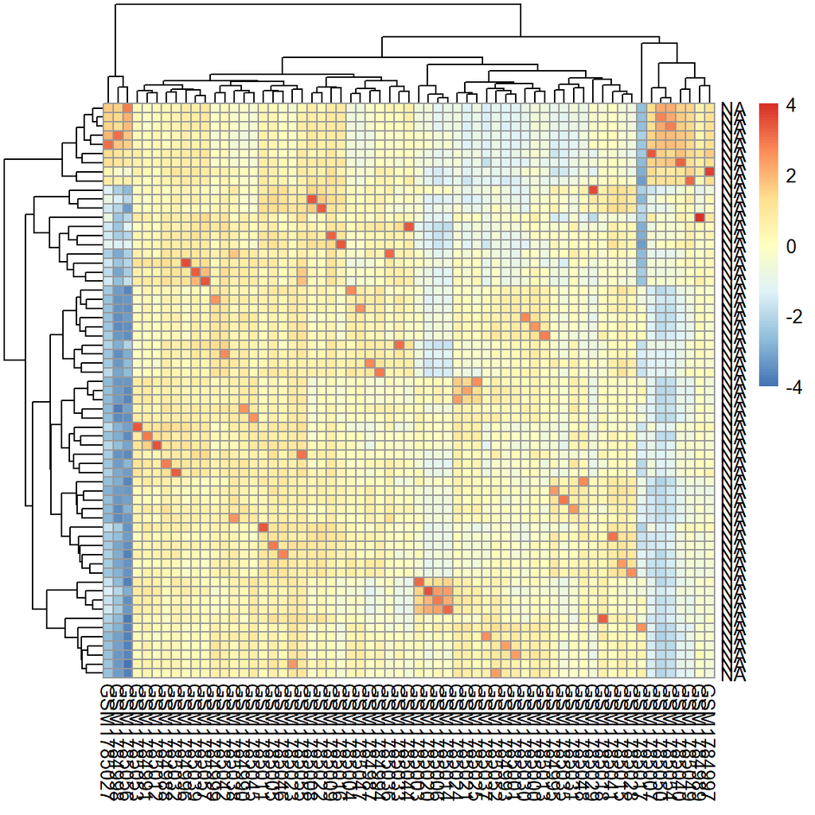

```r
## Hierarchical Clustering

library(pheatmap)
sampleInfo <- pData(gset)
gene_matrix <- cor(exprs(gset),use="c")

pheatmap(gene_matrix,
     labels_row = geneAnno$probeset_id,
     scale="row")
```

The study created its heatmap from utilising a dendrogram created from hierarchical clustering. This was done by isolating the differentially expressed genes that had a p-value of less than 0.05 using edgeR. Unfortunately, their methodologies on how this was performed (especially with a dataset with 70,000 probes) was unavailable.

After multiple attempts of trying to minimise the list of genes utilised and expressed on the heatmap, we were unable to reproduce this exactly, finding that methodologies which could do this successfully online utilised prior versions of rStudio which we did not have access to. Furthermore, it was not explicitly stated which form of hierarchical clustering was used within the data analysis.

```r
-log10(0.05)
```

```
## [1] 1.30103
```

```r
top100DE <- rownames(dt_fdr)[1:100]
top19DE <- rownames(dt_fdr)[1:19]
columnColour = pheno$gestational_diabetes
columnColour[pheno$gestational_diabetes == "Yes"] = "red"
columnColour[pheno$gestational_diabetes == "No"] = "white"
useColumns <- !is.na(columnColour)
```

## DAVID and KEGG

The manuscript, after these initial differential analyses, performed both an enrichment analysis via the DAVID tool and constructed a KEGG pathway network in order to create a gene regulatory network - in other words, create gene symbols to replace the gene IDs provided in the initial dataset.

For our reproduced report, we did not make use of the DAVID database as upon inspection it required all 70,000 probes to be manually typed in to observe the gene IDs. Furthermore, the KEGG pathway could also not be conducted due to the paper not being explicit in its use and contribution to the final results.

## SVM

```r
tab <- topTable(efit, coef = 2, adjust = "fdr", n = 10)
labCol <- c("Yes", "No")
top10 <- topTable(efit)

X <- t(exprs[rownames(top10), ])  # removed colnames[design] // wasnt needed

# Select outcome variable.
Y <- as.factor(pheno[, "gestational_diabetes"]) # as above, removed colnames[design] from left of comma

# test <- factor(rep(NA, n), levels = c("No", "Yes")) # dont need :(

# create new dataset.
gset1 <- data.frame(Y, X)

fit <- svm(Y ~ ., gset1)

predSVM <- predict(fit, gset1)  # Here we have predicted the classes of our original data.

mean(predSVM != gset1$Y) # value of 0.1269841
```

```
## [1] 0.1746032
```

The current paper utilised a support vector machine (SVM) to predict the potential application of the 6 found biomarkers in GDM clinical diagnosis. Through the creation of a test set and training set containing these particular data points, the study was able to obtain an error rate of 29.03%. In our reproduction of this prediction model, we got an error rate of 17.4%, which gives the impression that the dataset is not as accurate as what would typically be ideal within the scientific community. Despite this, it was still a better error rate than the original report, which leads to questions regarding the methodology within the paper and whether it misled our interpretation.

## randomForest

```r
library(randomForest)
fit <- randomForest(Y ~ ., gset1)
predrandomForest <- predict(fit, gset1)
predrandomForest <-factor(predrandomForest, levels = c("No", "Yes"))
predrandomForest
```

```
## GSM1784987 GSM1784988 GSM1784989 GSM1784990 GSM1784991 GSM1784993 GSM1784994
##        Yes        Yes        Yes         No        Yes         No        Yes
## GSM1784995 GSM1784996 GSM1784997 GSM1784998 GSM1784999 GSM1785000 GSM1785001
##        Yes        Yes        Yes         No        Yes        Yes         No
## GSM1785003 GSM1785004 GSM1785005 GSM1785006 GSM1785007 GSM1785008 GSM1785009
##         No         No         No         No        Yes        Yes        Yes
## GSM1785011 GSM1785012 GSM1785013 GSM1785014 GSM1785015 GSM1785016 GSM1785017
##        Yes        Yes         No         No        Yes        Yes         No
## GSM1785018 GSM1785020 GSM1785021 GSM1785022 GSM1785023 GSM1785024 GSM1785025
##        Yes         No         No         No        Yes         No         No
## GSM1785027 GSM1785028 GSM1785029 GSM1785030 GSM1785031 GSM1785032 GSM1785033
##         No         No         No        Yes         No        Yes         No
## GSM1785035 GSM1785036 GSM1785037 GSM1785038 GSM1785039 GSM1785040 GSM1785041
##         No         No         No         No        Yes        Yes        Yes
## GSM1785042 GSM1785044 GSM1785045 GSM1785046 GSM1785047 GSM1785048 GSM1785049
##        Yes         No        Yes        Yes        Yes        Yes         No
## GSM1785050 GSM1785052 GSM1785053 GSM1785054 GSM1785055 GSM1785056 GSM1785057
##         No        Yes         No         No        Yes         No        Yes
## Levels: No Yes
```

```r
gset1$Y
```

```
##  [1] Yes Yes Yes No  Yes No  Yes Yes Yes Yes No  Yes Yes No  No  No  No  No  Yes
## [20] Yes Yes Yes Yes No  No  Yes Yes No  Yes No  No  No  Yes No  No  No  No  No
## [39] Yes No  Yes No  No  No  No  No  Yes Yes Yes Yes No  Yes Yes Yes Yes No  No
## [58] Yes No  No  Yes No  Yes
## Levels: No Yes
```

```r
table(predrandomForest)
```

```
## predrandomForest
##  No Yes
##  31  32
```

```r
table(gset1$Y)
```

```
##
##  No Yes
##  31  32
```

```r
mean(predrandomForest != gset1$Y)
```

```
## [1] 0
```

```r
## Gave us zero so we do this...

set.seed(51773)
n <- nrow(gset1)
trainTest <- rep(c("train", "test"), 100)
trainTest <- trainTest[1:n]
trainTestSample <- sample(trainTest, n, replace = FALSE)
dataTrain <- gset1[trainTestSample == "train", ]
dataTest <- gset1[trainTestSample == "test", ]

fitforest <- randomForest(Y ~ ., dataTrain)
predrandomForest <- predict(fitforest, dataTest)
mean(predrandomForest != dataTest$Y)
```

```
## [1] 0.483871
```

# Appropriateness

## Methods

The study was able to successfully determine 6 biomarkers that could be used clinically in the diagnosis of GDM, thus achieving their goal, thus indicating that their methodology served its purpose and was correct in order to give the provided outcome. The methodology of utilising the DAVID database and KEGG pathway tools was found to be inappropriate as these programs were found to be inaccessible and difficult to use, especially when there was a requirement to manually insert the 70,000 probes - which in our time frame, was an unreachable goal.

Furthermore, there are doubts as to whether the methods have sufficient explanation in order to be reproducible for peer-reviews. So despite their benefit and success within this paper, it cannot be stated with confidence that the methods were appropriate due to the lack of reproducibility.

## Analysis

The analytical portion of the paper, particularly the SVM prediction model and 10-fold cross validation were for the most-part appropriate as they allowed for the determination of the validity of the model created within the study. For the prediction model, SVM is not the most appropriate choice for analysis due to the large scale of the data. Prediction models such as randomForest are better equipped for such datasets and thus would have potentially given a more accurate error rate and overall perspective of the predictive model created for the six biomarkers.

In regards to the 10-fold cross validation, we believe that this was an appropriate analytical method, as it provides the study with greater accuracy as to the fitting procedure as well as reduces both the variance and bias. Therefore, deciding to use a 10-fold cross validation over a 5-fold is ideal in this scenario.

# Successes and Difficulties

## Difficulties

As evident from the above reproduced report, we encountered many difficulties with the paper. One of our greatest weaknesses in reproducing the report was some of the databases and programs utilised by the paper, such as DAVID and KEGGS, which were difficult and too time-consuming to utilise as intended by the paper. In turn, this meant that we were unable to create gene symbols within our reproduced report, which led to many difficulties later on in the paper. Additionally, we had difficulty in reproducing many components of the report due to the ambiguous nature of the writing. There was a lack of sufficient detail that would typically be required in order to reproduce someones findings in the case of peer-reviews. This may have been due to the fact that this dataset was not created by the authors of the paper we looked at, rather they used another papers dataset and created their own interpretation of the findings through analytical methods on rStudio. This could have led to a mis-translation within the methods section, thus making it difficult to reproduce.

overall, whilst a difficult paper to reproduce, we have learnt a lot about the difficulties of data analysis and interpretation, especially with such large datasets. It can be difficult to manage and organise, as well as interpret. This project has given all team members a great appreciation for the complexities of such work.

## Improvements to Workflow

Potential improvements to the workflow would include the use of other programs within rStudio rather than DAVID and KEGG to avoid unneccessary complexities within the methodology of extracting information from the provided dataset. Whether this be through re-working the existing dataset to create subsets or creating a clear pathway to extracting the necessary gene symbols in order for the subsequent coding and findings to be parallel to that of the paper.